# Wrangle Seattle collision data

Leah Erb

# Libraries and functions

```r
# libraries
library(data.table) # renaming columns
library(gtable)
library(stringr)    # 'word' function
library(dplyr)
library(tidyverse)
library(knitr)
library(grid)       # table grid
library(gridExtra)  # table grid

print_date_range <- function(this_df){
    # Prints min and max INCDATE of this_df
    this_df %>%
        summarize(min_INCDATE = min(as.Date(this_df$INCDATE)),
                  max_INCDATE = max(as.Date(this_df$INCDATE)))
}

print_null_count <- function(this_df) {
    # Print columns with NULLs and their counts
    dfNulls <- sapply(df, function(x) sum(is.na(x)))
    as.data.frame(dfNulls[dfNulls > 0]) %>% rename_at(1, ~'null_count')
}

# helper function
count_vals <- function(this_df) {
    # Return value counts and proportions of this_df
    return(
        this_df %>%
            tally() %>%
            mutate(freq = (n_pct = (n / sum(n)) * 100))
    )
}

print_value_counts <- function(this_df, cols) {
    # Print value count and proportions of a list of columns
    lapply(this_df[cols], function(x) {
        x <- enquo(x)
        kable(
        df %>%
            group_by(fct_explicit_na(!! x)) %>%
            count_vals
        , caption = deparse(substitute(this_df)))
    })
}

options(scipen=6)
get_column_values <- function(this_df, cols) {
    # Print value count and proportions of a list of columns
    result <- lapply(this_df[cols], function(x) {
        x <- enquo(x)
        kable(         # kable because knitr uses scientific notation instead of decimal.
        this_df %>%
            group_by(fct_explicit_na(!! x)) %>%
            count_vals
        , caption = deparse(substitute(this_df)))  # print this_df name not value
    })

    return (result)
}
```

# Load data

```r
# toggle data source: local file or live site  TODO: default to live site
local_datafile = '../data/collisions.csv'
datafile = local_datafile
#datafile = 'http://data-seattlecitygis.opendata.arcgis.com/datasets/5b5c745e0f1f48e7a53acec63a0022ab_0.csv'

df = read.csv(datafile, na.strings=c("", " "), header=TRUE)

# save to csv for off-line loading next time
#write.csv(df, file = local_datafile)
```

# Assess

```r
glimpse(df)
```

```
Observations: 210,200
Variables: 41
$ X.1             <int> 1, 2, 3, 4, 5, 6, 7, 8, 9, 10, 11, 12, 13, 14, 1…
$ X               <fct> -122.322010241134, -122.320702903796, -122.36204…
$ Y               <fct> 47.6042329327014, 47.664957731244, 47.7115608047…
$ OBJECTID        <int> 2001, 2002, 2003, 2004, 2005, 2006, 2007, 2008, …
$ INCKEY          <int> 142500, 142400, 178900, 141700, 142200, 178500, …
$ COLDETKEY       <int> 142500, 142400, 178940, 141700, 142200, 178540, …
$ REPORTNO        <fct> 3552040, 3508127, 3590736, 3505797, 3508063, 357…
$ STATUS          <fct> Matched, Matched, Matched, Matched, Matched, Mat…
$ ADDRTYPE        <fct> Block, Intersection, Block, Intersection, Block,…
$ INTKEY          <fct> NA, 25786, NA, 29872, NA, NA, NA, 35896, 29933, …
$ LOCATION        <fct> TERRY AVE BETWEEN ALDER ST AND TERRACE ST, 7TH A…
$ EXCEPTRSNCODE   <fct> NA, NA, NEI, NA, NA, NA, NA, NA, NA, NA, NA, NA,…
$ EXCEPTRSNDESC   <fct> "NA", "NA", "Not Enough Information, or Insuffic…
```

[output cut: 28 more lines]

#### What do Date/time columns look like?

```r
head(df$INCDATE, 20)
```

```
 [1] 2012-03-22T00:00:00.000Z 2012-10-15T00:00:00.000Z
 [3] 2014-10-25T00:00:00.000Z 2012-04-13T00:00:00.000Z
 [5] 2012-11-30T00:00:00.000Z 2014-10-30T00:00:00.000Z
 [7] 2014-10-24T00:00:00.000Z 2012-11-02T00:00:00.000Z
 [9] 2014-10-25T00:00:00.000Z 2012-09-30T00:00:00.000Z
[11] 2012-08-03T00:00:00.000Z 2012-08-05T00:00:00.000Z
[13] 2011-08-31T00:00:00.000Z 2013-01-19T00:00:00.000Z
[15] 2014-11-25T00:00:00.000Z 2013-03-06T00:00:00.000Z
[17] 2014-12-08T00:00:00.000Z 2013-01-30T00:00:00.000Z
[19] 2014-12-03T00:00:00.000Z 2014-11-28T00:00:00.000Z
5641 Levels: 2003-10-06T00:00:00.000Z ... 2019-06-10T00:00:00.000Z
```

```r
head(df$INCDTTM, 20)
```

```
 [1] 3/22/2012 5:41:00 PM   10/15/2012 9:47:00 AM  10/25/2014 10:00:00 PM
 [4] 4/13/2012 5:30:00 PM   11/30/2012 12:00:00 PM 10/30/2014 9:43:00 PM
 [7] 10/24/2014 1:00:00 PM  11/2/2012 4:42:00 PM   10/25/2014 2:28:00 AM
[10] 9/30/2012 7:40:00 PM   8/3/2012 7:15:00 AM    8/5/2012 5:33:00 PM
[13] 8/31/2011 3:14:00 PM   1/19/2013 11:58:00 PM  11/25/2014 7:00:00 PM
[16] 3/6/2013 11:57:00 PM   12/8/2014 12:04:00 PM  1/30/2013 10:00:00 AM
[19] 12/3/2014 5:53:00 PM   11/28/2014 7:27:00 PM
159346 Levels: 1/1/2004 1/1/2005 1/1/2006 1/1/2007 1/1/2008 ... 9/9/2018 9:45:00 PM
```

**Observation:** INCDATE does not contain time, INCDTTM includes dates and sometimes time.

#### What is our date range, and how many records in each year?

```r
print_date_range(df)
```

| min_INCDATE | max_INCDATE |
| --- | --- |
| 2003-10-06 | 2019-06-10 |

```r
df %>%
    mutate(year = lubridate::year(as.Date(df$INCDATE))) %>%
    group_by(year) %>%
    tally()
```

| year | n |
| --- | --- |
| 2003 | 1 |
| 2004 | 15457 |
| 2005 | 16016 |
| 2006 | 15794 |
| 2007 | 15082 |
| 2008 | 14139 |
| 2009 | 13275 |
| 2010 | 11958 |
| 2011 | 12416 |
| 2012 | 12732 |

[output cut: 7 more lines]

**Observation:** We have an outlier in year 2003, and the lastest year may not be a full 12 month’s worth of data.

#### Which columns have NULL values, and how many are there?

```r
print_null_count(df)
```

| null_count |
| --- |

**Observation:** date and datetime columns have no NULL values.

#### Several columns have only 1 NULL, are they all from the same record?

```r
cols <-  c('SEVERITYCODE', 'SDOT_COLDESC', 'SDOT_COLCODE')
subset(df, is.na(SEVERITYCODE) | is.na(SDOT_COLCODE) | is.na(SDOT_COLDESC), cols)
```

| SEVERITYCODE | SDOT_COLDESC | SDOT_COLCODE |
| --- | --- | --- |

**Observation:** No.

#### Can we deduce a value for the missing SDOT_COLCODE, given other values in the record?

```r
subset(df, is.na(SDOT_COLCODE))
```

| X.1 | X | Y | OBJECTID | INCKEY | COLDETKEY | REPORTNO | STATUS | ADDRTYPE | INTKEY | LOCATION | EXCEPTRSNCODE | EXCEPTRSNDESC | SEVERITYCODE | SEVERITYDESC | COLLISIONTYPE | PERSONCOUNT | PEDCOUNT | PEDCYLCOUNT | VEHCOUNT | INJURIES | SERIOUSINJURIES | FATALITIES | INCDATE | INCDTTM | JUNCTIONTYPE | SDOT_COLCODE | SDOT_COLDESC | INATTENTIONIND | UNDERINFL | … |
| --- | --- | --- | --- | --- | --- | --- | --- | --- | --- | --- | --- | --- | --- | --- | --- | --- | --- | --- | --- | --- | --- | --- | --- | --- | --- | --- | --- | --- | --- | --- |

**Observation:** No. There is very little information recorded. Suspiciously, record is dated 2003 which is the only record for that year. I hypothesize that the 2003 record was a test insert.

#### Can we deduce a value for the NULL SEVERITYCODE, given other values in the record?

```r
subset(df, is.na(SEVERITYCODE))
```

| X.1 | X | Y | OBJECTID | INCKEY | COLDETKEY | REPORTNO | STATUS | ADDRTYPE | INTKEY | LOCATION | EXCEPTRSNCODE | EXCEPTRSNDESC | SEVERITYCODE | SEVERITYDESC | COLLISIONTYPE | PERSONCOUNT | PEDCOUNT | PEDCYLCOUNT | VEHCOUNT | INJURIES | SERIOUSINJURIES | FATALITIES | INCDATE | INCDTTM | JUNCTIONTYPE | SDOT_COLCODE | SDOT_COLDESC | INATTENTIONIND | UNDERINFL | … |
| --- | --- | --- | --- | --- | --- | --- | --- | --- | --- | --- | --- | --- | --- | --- | --- | --- | --- | --- | --- | --- | --- | --- | --- | --- | --- | --- | --- | --- | --- | --- |

**Observation:** Yes. The NULL SEVERITYCODE could be changed to ‘0’ because INJURY, SERIOUSINJURIES and FATALITIES = 0

#### What do SEVERITYCODE and SEVERITYDESC look like?

```r
df %>%
    group_by(fct_explicit_na(SEVERITYCODE), fct_explicit_na(SEVERITYDESC)) %>%
    summarize(n = n())
```

| fct_explicit_na(SEVERITYCODE) | fct_explicit_na(SEVERITYDESC) | n |
| --- | --- | --- |
| 0 | Unknown | 20427 |
| 1 | Property Damage Only Collision | 130941 |
| 2 | Injury Collision | 55583 |
| 2b | Serious Injury Collision | 2929 |
| 3 | Fatality Collision | 319 |
| NA | Unknown | 1 |

#### There are also 3 columns with counts of INJURIES, SERIOUSINJURIES and FATALITIES (but not a count for property damage). Are the SEVERITYCODE/SEVERITYDESC values derived directly from the counts that are > 0?

```r
category <- c('Unknown', 'Injury Collision','Serious Injury Collision','Fatality Collision')

df %>%
    mutate(., fake_severitydesc = with(., case_when(
        (FATALITIES > 0) ~ 'Fatality Collision',
        (SERIOUSINJURIES > 0) ~ 'Serious Injury Collision',
        (INJURIES > 0) ~ 'Injury Collision' #
    ))) %>%
    group_by(fake_severitydesc) %>%
    summarize(n = n()) %>%
    slice(match(category, fake_severitydesc))  # order rows by severity category
```

| fake_severitydesc | n |
| --- | --- |
| Injury Collision | 55632 |
| Serious Injury Collision | 2879 |
| Fatality Collision | 319 |

```r
df %>% filter(
        (SEVERITYDESC == 'Fatality Collision' & FATALITIES == 0) |
        (SEVERITYDESC == 'Injury Collsion' & INJURIES == 0) |
        (SEVERITYDESC == 'Serious Injury Collision' & SERIOUSINJURIES == 0) |
        ((FATALITIES + INJURIES + SERIOUSINJURIES > 0) &
             SEVERITYCODE %in% c('0','1')) # Unknown or Property Damage
        ) %>%
    arrange(SDOT_COLDESC)
```

| X.1 | X | Y | OBJECTID | INCKEY | COLDETKEY | REPORTNO | STATUS | ADDRTYPE | INTKEY | LOCATION | EXCEPTRSNCODE | EXCEPTRSNDESC | SEVERITYCODE | SEVERITYDESC | COLLISIONTYPE | PERSONCOUNT | PEDCOUNT | PEDCYLCOUNT | VEHCOUNT | INJURIES | SERIOUSINJURIES | FATALITIES | INCDATE | INCDTTM | JUNCTIONTYPE | SDOT_COLCODE | SDOT_COLDESC | INATTENTIONIND | UNDERINFL | … |
| --- | --- | --- | --- | --- | --- | --- | --- | --- | --- | --- | --- | --- | --- | --- | --- | --- | --- | --- | --- | --- | --- | --- | --- | --- | --- | --- | --- | --- | --- | --- |
| 1395 | -122.312642086326 | 47.6220883824264 | 3395 | 16715 | 16715 | 3593815 | Unmatched | Intersection | 29033 | 15TH AVE E AND E HARRISON N ST | NA | NA | 2b | Serious Injury Collision | NA | 2 | 0 | 0 | 0 | 1 | 0 | 0 | 2013-04-10T00:00:00.000Z | 4/10/2013 | At Intersection (intersection related) | 24 | MOTOR VEHCILE STRUCK PEDESTRIAN | NA | NA | … |
| 130885 | -122.316872849488 | 47.6164321917269 | 130885 | 146519 | 146539 | 3330815 | Unmatched | Intersection | 29729 | 12TH AVE AND E OLIVE ST | NA | NA | 2b | Serious Injury Collision | NA | 1 | 0 | 0 | 0 | 1 | 0 | 0 | 2013-05-18T00:00:00.000Z | 5/18/2013 | At Intersection (intersection related) | 24 | MOTOR VEHCILE STRUCK PEDESTRIAN | NA | NA | … |
| 163006 | -122.318187618208 | 47.6170052670336 | 163006 | 203888 | 204028 | C802692 | Unmatched | Block | NA | 11TH AVE BETWEEN E OLIVE ST AND E HOWELL ST | NA | NA | 2b | Serious Injury Collision | NA | 1 | 0 | 0 | 0 | 1 | 0 | 0 | 2015-05-17T00:00:00.000Z | 5/17/2015 | Mid-Block (not related to intersection) | 24 | MOTOR VEHCILE STRUCK PEDESTRIAN | NA | NA | … |
| 176348 | -122.28563111156 | 47.546057245843 | 176348 | 227937 | 228277 | 3754585 | Unmatched | Intersection | 33645 | M L KING JR WR WAY S AND S GRAHAM ST | NA | NA | 2b | Serious Injury Collision | NA | 4 | 0 | 0 | 0 | 1 | 0 | 0 | 2016-09-30T00:00:00.000Z | 9/30/2016 | At Intersection (intersection related) | 24 | MOTOR VEHCILE STRUCK PEDESTRIAN | NA | NA | … |
| 176510 | -122.309392708163 | 47.5930814573871 | 176510 | 226062 | 226402 | 3707528 | Unmatched | Block | NA | RAINIER AVE S BETWEEN S NORMAN ST AND I90 WB RAINIER NB OF RP | NA | NA | 2b | Serious Injury Collision | NA | 1 | 0 | 0 | 0 | 1 | 0 | 0 | 2016-08-18T00:00:00.000Z | 8/18/2016 | Mid-Block (not related to intersection) | 24 | MOTOR VEHCILE STRUCK PEDESTRIAN | NA | NA | … |
| 177160 | -122.270583884758 | 47.5190424497062 | 177160 | 225697 | 226037 | 3673578 | Unmatched | Block | NA | S FLETCHER ST BETWEEN 50TH AVE S AND 51ST AVE S | NA | NA | 2b | Serious Injury Collision | NA | 2 | 0 | 0 | 0 | 1 | 0 | 0 | 2016-08-04T00:00:00.000Z | 8/4/2016 | Mid-Block (not related to intersection) | 24 | MOTOR VEHCILE STRUCK PEDESTRIAN | NA | NA | … |
| 183169 | -122.32341547054 | 47.6152311420802 | 183169 | 238885 | 239325 | 3773565 | Unmatched | Intersection | 29734 | BOYLSTON AVE AND E PINE ST | NA | NA | 2b | Serious Injury Collision | NA | 4 | 0 | 0 | 0 | 2 | 0 | 0 | 2017-04-13T00:00:00.000Z | 4/13/2017 | At Intersection (intersection related) | 24 | MOTOR VEHCILE STRUCK PEDESTRIAN | NA | NA | … |
| 196144 | -122.329054585517 | 47.5829366189919 | 196144 | 317225 | 318725 | 3754709 | Unmatched | Block | NA | 4TH AVE S BETWEEN S WALKER ST AND S STACY ST | NA | NA | 2b | Serious Injury Collision | NA | 2 | 0 | 0 | 0 | 1 | 0 | 0 | 2019-04-09T00:00:00.000Z | 4/9/2019 | Mid-Block (not related to intersection) | 24 | MOTOR VEHCILE STRUCK PEDESTRIAN | NA | NA | … |
| 201915 | -122.308739597137 | 47.6204914374088 | 202915 | 304017 | 305257 | 3814042 | Unmatched | Intersection | 29368 | 18TH AVE E AND E THOMAS ST | NA | NA | 2b | Serious Injury Collision | NA | 2 | 0 | 0 | 0 | 1 | 0 | 0 | 2018-10-01T00:00:00.000Z | 10/1/2018 | At Intersection (intersection related) | 24 | MOTOR VEHCILE STRUCK PEDESTRIAN | NA | NA | … |
| 207115 | -122.252386051475 | 47.5072893329169 | 207115 | 318297 | 319797 | 3805727 | Unmatched | Block | NA | 65TH AVE S BETWEEN S PRENTICE ST AND S BANGOR ST | NA | NA | 2b | Serious Injury Collision | NA | 1 | 0 | 0 | 0 | 1 | 0 | 0 | 2019-04-29T00:00:00.000Z | 4/29/2019 | Mid-Block (not related to intersection) | 24 | MOTOR VEHCILE STRUCK PEDESTRIAN | NA | NA | … |

[output cut: 40 more lines]

**Observations:** Not that I can see, other than many of the factor values are null.

#### There are several collision type columns, what do they look like?

```r
# Print count and % of column values
cols <- c('COLLISIONTYPE', 'SDOT_COLDESC', 'ST_COLDESC')
get_column_values(df, cols)
```

```
$COLLISIONTYPE


Table: this_df

fct_explicit_na(...)        n    freq
---------------------  ------  ------
Angles                  33487   15.93
Cycles                   5540    2.64
Head On                  2062    0.98
Left Turn               13385    6.37
NA                      24958   11.87
Other                   23402   11.13
Parked Car              46598   22.17
Pedestrian               7123    3.39
Rear Ended              33003   15.70
Right Turn               2874    1.37
Sideswipe               17768    8.45

$SDOT_COLDESC


Table: this_df

fct_explicit_na(...)                                                n    freq
-------------------------------------------------------------  ------  ------
DRIVERLESS VEHICLE RAN OFF ROAD - HIT FIXED OBJECT                112    0.05
DRIVERLESS VEHICLE RAN OFF ROAD - NO COLLISION                      2    0.00
DRIVERLESS VEHICLE STRUCK MOTOR VEHICLE FRONT END AT ANGLE        108    0.05
DRIVERLESS VEHICLE STRUCK MOTOR VEHICLE LEFT SIDE AT ANGLE         55    0.03
DRIVERLESS VEHICLE STRUCK MOTOR VEHICLE LEFT SIDE SIDESWIPE         4    0.00
DRIVERLESS VEHICLE STRUCK MOTOR VEHICLE REAR END                   98    0.05
DRIVERLESS VEHICLE STRUCK MOTOR VEHICLE RIGHT SIDE AT ANGLE        12    0.01
DRIVERLESS VEHICLE STRUCK MOTOR VEHICLE RIGHT SIDE SIDESWIPE        6    0.00
DRIVERLESS VEHICLE STRUCK OBJECT IN ROADWAY                         4    0.00
DRIVERLESS VEHICLE STRUCK PEDESTRIAN                               15    0.01
MOTOR VEHCILE STRUCK PEDESTRIAN                                  7177    3.41
MOTOR VEHICLE OVERTURNED IN ROAD                                  551    0.26
MOTOR VEHICLE RAN OFF ROAD - HIT FIXED OBJECT                    9169    4.36
MOTOR VEHICLE RAN OFF ROAD - NO COLLISION                         163    0.08
```

[output cut: 82 more lines]

```
Vehicle backing hits pedestrian                                                            237    0.11
Vehicle going straight hits pedestrian                                                    3308    1.57
Vehicle Hits City Road or Construction Machinery                                            50    0.02
Vehicle Hits Other Road or Construction Machinery                                           11    0.01
Vehicle hits Pedestrian - All Other Actions                                                120    0.06
Vehicle Hits State Road or Construction Machinery                                            1    0.00
Vehicle overturned                                                                         889    0.42
Vehicle Strikes All Other Non-Domestic Animal                                                2    0.00
Vehicle Strikes Deer                                                                         1    0.00
Vehicle Strikes Pedalcyclist                                                               272    0.13
Vehicle Strikes Railway Vehicle                                                             53    0.03
Vehicle Struck by City Road or Construction Machinery                                       11    0.01
Vehicle Struck by Other Road or Construction Machinery                                       9    0.00
Vehicle turning left hits pedestrian                                                      2247    1.07
Vehicle turning right hits pedestrian                                                     1211    0.58
```

**Observations:**

- SDOT_COLDESC has a misspelling (MOTOR VEHCILE STRUCK PEDESTRIAN)
- COLLISIONTYPE has fewest categories (10 non-null). We do not know how this data was created. Can we reverse-engineer SDOT_COLCODE or ST_COLCODE to re-create COLLISIONTYPE?
- SDOT_COLDESC clearly identifies what did the striking (DRIVERLESS, MOTOR VEHICLE or PEDALCYCLIST) and what got struck
- ST_COLDESC has the most categories (62 non-null) that include more details than SDOT_COLDESC

According to the Collisions_OD.pdf:

- SDOT_COLDESC is given to the collision by Seattle Department of Transportation
- ST_COLDESC is a code supplied by the State

#### Are SDOT_COLCODE and SDOT_COLDESC values 1:1? (Seattle Dept of Transportation)

```r
df %>%
    group_by(SDOT_COLCODE, SDOT_COLDESC) %>%
    summarise(count = n())
```

| SDOT_COLCODE | SDOT_COLDESC | count |
| --- | --- | --- |
| 0 | NOT ENOUGH INFORMATION / NOT APPLICABLE | 18522 |
| 11 | MOTOR VEHICLE STRUCK MOTOR VEHICLE, FRONT END AT ANGLE | 86895 |
| 12 | MOTOR VEHICLE STRUCK MOTOR VEHICLE, RIGHT SIDE AT ANGLE | 1717 |
| 13 | MOTOR VEHICLE STRUCK MOTOR VEHICLE, LEFT SIDE AT ANGLE | 6643 |
| 14 | MOTOR VEHICLE STRUCK MOTOR VEHICLE, REAR END | 56310 |
| 15 | MOTOR VEHICLE STRUCK MOTOR VEHICLE, RIGHT SIDE SIDESWIPE | 1744 |
| 16 | MOTOR VEHICLE STRUCK MOTOR VEHICLE, LEFT SIDE SIDESWIPE | 10555 |
| 18 | MOTOR VEHICLE STRUCK PEDALCYCLIST, FRONT END AT ANGLE | 3197 |
| 21 | MOTOR VEHICLE STRUCK PEDALCYCLIST, REAR END | 201 |
| 22 | MOTOR VEHICLE STRUCK PEDALCYCLIST, RIGHT SIDE SIDESWIPE | 19 |

[output cut: 30 more lines]

**Observations:** Yes.

#### Are ST_COLCODE and ST_COLDESC values 1:1? (State’s codes)

```r
df %>%
    group_by(ST_COLCODE, ST_COLDESC) %>%
    summarise(count = n())
```

| ST_COLCODE | ST_COLDESC | count |
| --- | --- | --- |
| 0 | Vehicle going straight hits pedestrian | 3308 |
| 1 | Vehicle turning right hits pedestrian | 1211 |
| 10 | Entering at angle | 33487 |
| 11 | From same direction - both going straight - both moving - sideswipe | 12197 |
| 12 | From same direction - both going straight - one stopped - sideswipe | 2312 |
| 13 | From same direction - both going straight - both moving - rear-end | 7338 |
| 14 | From same direction - both going straight - one stopped - rear-end | 24998 |
| 15 | From same direction - one left turn - one straight | 2995 |
| 16 | From same direction - one right turn - one straight | 2874 |
| 17 | Strikes or Was Struck by Object from the Load of Another Vehicle | 4 |

[output cut: 53 more lines]

**Observations:** Yes.

#### Let’s reconcile the 3 categories by validating:

1. if COLLISIONTYPE can be reverse-engineered from ST_COLDESC (suggesting COLLISIONTYPE is a generated column, not a collision report feature)
2. if #1 is true, were there any value compromises made to create COLLISIONTYPE
3. SDOT_COLDESC and ST_COLDESC do not contradict

**1. Can we reverse-engineer ST_COLDESC to create COLLISIONTYPE, and are any compromises made to do so?**

```r
# See if we can reverse-engineer ST_COLDESC into COLLISIONTYPE.
# TODO: repeat this programmatically using string parsing, see if we can duplicate how COLLISIONTYPE may have been done.
# (Ref: State Collision Code Directory https://www.seattle.gov/Documents/Departments/SDOT/GIS/Collisions_OD.pdf)

# temporarily set as integer during mutate
df$ST_COLCODE <- as.integer(df$ST_COLCODE)
df <- df %>%
    mutate(., ST_COLDESC_collisiontype = with(., case_when(
        (ST_COLCODE <= 5) ~ 'Pedestrian',  #'Vehicle Hits Pedestrian', + "Vehicle Strikes Pedalcyclist (#5)"
        (ST_COLCODE >= 6 & ST_COLCODE <= 8) ~ 'Cycles',  # Pedalcyclist hits something
        (ST_COLCODE == 10) ~ 'Angles',     #'Entering at angle',
        (ST_COLCODE >= 11 & ST_COLCODE <= 12) ~ 'Sideswipe',
        (ST_COLCODE >= 13 & ST_COLCODE <= 14) ~ 'Rear Ended',
        (ST_COLCODE == 15) ~ 'Left Turn',
        (ST_COLCODE == 16) ~ 'Right Turn',
        (ST_COLCODE >= 19 & ST_COLCODE <= 20) ~ 'Parked Car', #'Entering/Leaving Parking',
        (ST_COLCODE >= 21 & ST_COLCODE <= 22) ~ 'Other', #'Entering/Leaving Driveway',
        (ST_COLCODE == 23) ~ 'Other',
        (ST_COLCODE >= 24 & ST_COLCODE <= 25) ~ 'Head On',
        (ST_COLCODE >= 26 & ST_COLCODE <= 27) ~ 'Sideswipe',
        (ST_COLCODE == 28) ~ 'Left Turn',
        (ST_COLCODE == 29) ~ 'Left Turn',                 # THIS IS A COMPROMISE (actual: 1 left, 1 right)
        (ST_COLCODE == 30) ~ 'Head On',  #'From opposite direction - all others',
        (ST_COLCODE == 32) ~ 'Parked Car',                #'One parked--one moving',
        (ST_COLCODE >= 40 & ST_COLCODE <= 43) ~ 'Other', # Involving Railway Vehicle,
        (ST_COLCODE >= 44 & ST_COLCODE <= 46) ~ 'Cycles', #'Pedalcyclist',
        (ST_COLCODE >= 47 & ST_COLCODE <= 51) ~ 'Other',  # 'Struck Object',
        (ST_COLCODE >= 52 & ST_COLCODE <= 57) ~ 'Other',  # 'Non-Collision',
        (ST_COLCODE >= 71 & ST_COLCODE <= 72) ~ 'Sideswipe',
        (ST_COLCODE >= 73 & ST_COLCODE <= 74) ~ 'Rear Ended',
        (ST_COLCODE >= 81 & ST_COLCODE <= 82) ~ 'Sideswipe',
        (ST_COLCODE >= 83 & ST_COLCODE <= 84) ~ 'Rear Ended',
        is.na(ST_COLCODE) ~ 'Unknown', #NA_character_,
        TRUE ~ 'Other'   # as.character(.$ST_COLDESC)
    )))
df$ST_COLCODE <- as.factor(df$ST_COLCODE)

# validate
print_value_counts(df, 'ST_COLDESC_collisiontype')
```

```
$ST_COLDESC_collisiontype


Table: this_df

fct_explicit_na(...)        n    freq
---------------------  ------  ------
Angles                      4    0.00
Cycles                  35536   16.91
Head On                  1581    0.75
Left Turn                1864    0.89
Other                   66379   31.58
Parked Car               1138    0.54
Pedestrian              52515   24.98
Rear Ended               4970    2.36
Right Turn               2292    1.09
Sideswipe               43921   20.89
```

```r
print_value_counts(df, 'COLLISIONTYPE')
```

```
$COLLISIONTYPE


Table: this_df

fct_explicit_na(...)        n    freq
---------------------  ------  ------
Angles                  33487   15.93
Cycles                   5540    2.64
Head On                  2062    0.98
Left Turn               13385    6.37
NA                      24958   11.87
Other                   23402   11.13
Parked Car              46598   22.17
Pedestrian               7123    3.39
Rear Ended              33003   15.70
Right Turn               2874    1.37
Sideswipe               17768    8.45
```

**Can we do the same reverse-engineering using ST_COLDESC (instead of ST_COLCODE), parsing string values (e.g. look for ‘Pedestrian’)?

```r
df$ST_collisiontype <- tolower(df$ST_COLDESC)

df <- df %>%
    mutate(., ST_collisiontype = with(., case_when(
        (str_detect(ST_collisiontype, 'pedestrian')) ~ 'Pedestrian',
        #(str_detect(ST_collisiontype, 'angle')) ~ 'Angles',
        #(str_detect(ST_collisiontype, 'pedalcyclist')) ~ 'Cycles',
        #(str_detect(ST_collisiontype, 'left')) ~ 'Left Turn',
        #(str_detect(ST_collisiontype, 'right')) ~ 'Right Turn',
         TRUE ~ 'Other'
    )))

print_value_counts(df, 'ST_collisiontype')
```

```
$ST_collisiontype


Table: this_df

fct_explicit_na(...)         n   freq
---------------------  -------  -----
Other                   203047   96.6
Pedestrian                7153    3.4
```

**Observations:** No.

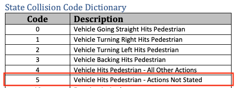

```r
# create df of collision types 0-5 (vehicle hits something), order by st_colcode
d <- df %>%
    filter(as.integer(ST_COLCODE) <= 5) %>%
    distinct(ST_COLCODE, ST_COLDESC) %>%
    arrange(ST_COLCODE)

# until knitr issue resolved in next two chunks, print d in ugly format
d
```

| ST_COLCODE | ST_COLDESC |
| --- | --- |
| 1 | Vehicle going straight hits pedestrian |
| 2 | Vehicle turning right hits pedestrian |
| 3 | Entering at angle |
| 4 | From same direction - both going straight - both moving - sideswipe |
| 5 | From same direction - both going straight - one stopped - sideswipe |

```r
# this chunk throwing an error only in knitr so set eval=FALSE for now
# create framework for table of our vehicle-hits-something df
hj <- matrix(c(.5, 0), ncol=2, nrow=nrow(d), byrow=TRUE)
x <- matrix(c(.5, 0), ncol=2, nrow=nrow(d), byrow=TRUE)

# stylize table
mytheme <- ttheme_default(core = list(fg_params =
                                          list(hjust=as.vector(hj),
                                               x=as.vector(x))),
                          colhead = list(fg_params = list(fontface="bold")))

# put table frame and style together
tg <- tableGrob(d, theme = mytheme, rows=NULL)  # no row-index

# manually make font color red for text in cells 10 and 16 (our row of interest)
for (i in c(10,16)) {
    tg$grobs[[i]] <- editGrob(tg$grobs[[i]],
                              gp=gpar(col="red",fontsize = '14'))
}

# initialize
grid.newpage()
grid.draw(tg)
```

**Add a title to the graph.** TODO: find a simpler way to plot the table with a title.

```r
title <- textGrob("Collisions Dataset",gp=gpar(fontsize=16))
padding <- unit(5,"mm")

table <- gtable_add_rows(
     tg,
     heights = grobHeight(title) + padding,
     pos = 0)
table <- gtable_add_grob(
    table,
    title,
    1, 1, 1, ncol(table))

grid.newpage()
grid.draw(table)
```

**3. Do SDOT_COLDESC and ST_COLDESC values contradict?

```r
# Do a litmus test on 'pedalcyclist' contradictions
df %>% filter(!is.na(ST_COLDESC)) %>%
    filter((str_detect(tolower(ST_COLDESC), 'pedalcyclist') & !str_detect(tolower(SDOT_COLDESC), 'pedalcyclist')) |
               (!str_detect(tolower(ST_COLDESC), 'pedalcyclist') & str_detect(tolower(SDOT_COLDESC), 'pedalcyclist'))) %>%
    group_by(SDOT_COLDESC, ST_COLDESC, PEDCYLCOUNT, PEDCOUNT) %>%
    summarize(n = n())
```

| SDOT_COLDESC | ST_COLDESC | PEDCYLCOUNT | PEDCOUNT | n |
| --- | --- | --- | --- | --- |
| DRIVERLESS VEHICLE STRUCK MOTOR VEHICLE FRONT END AT ANGLE | Vehicle - Pedalcyclist | 1 | 0 | 1 |
| DRIVERLESS VEHICLE STRUCK MOTOR VEHICLE LEFT SIDE SIDESWIPE | Vehicle - Pedalcyclist | 2 | 0 | 1 |
| MOTOR VEHCILE STRUCK PEDESTRIAN | Pedalcyclist Strikes Moving Vehicle | 0 | 1 | 1 |
| MOTOR VEHCILE STRUCK PEDESTRIAN | Pedalcyclist Strikes Moving Vehicle | 1 | 0 | 1 |
| MOTOR VEHCILE STRUCK PEDESTRIAN | Pedalcyclist Strikes Pedalcyclist or Pedestrian | 1 | 1 | 4 |
| MOTOR VEHCILE STRUCK PEDESTRIAN | Vehicle - Pedalcyclist | 1 | 0 | 26 |
| MOTOR VEHCILE STRUCK PEDESTRIAN | Vehicle - Pedalcyclist | 1 | 1 | 7 |
| MOTOR VEHCILE STRUCK PEDESTRIAN | Vehicle Strikes Pedalcyclist | 1 | 0 | 4 |
| MOTOR VEHICLE OVERTURNED IN ROAD | Vehicle - Pedalcyclist | 1 | 0 | 7 |
| MOTOR VEHICLE RAN OFF ROAD - HIT FIXED OBJECT | Railway Vehicle Strikes Pedalcyclist | 0 | 0 | 1 |

[output cut: 98 more lines]

**Observations:** Possibly. There are also possible contradictions with counts-of-things such as PEDCYCLCOUNT and PEDCOUNT.

I did a litmus test to see if the word ‘pedalcyclist’ shows up in both the SDOT and State’s collision descriptions. There are well over 500 contradictions on ‘pedalcyclist’ alone. For example, SDOT_COLDESC = ‘MOTOR VEHICLE STRUCK MOTOR VEHICLE…’ and ST_COLDESC = ‘Vehicle - Pedalcyclist’ (117 records).

Also, there are some records where SDOT claims ‘…STRUCK PEDALCYCLIST’ **yet** PEDCYCLCOUNT = 0 and PEDCOUNT = 0.

#### What do binary-esque columns look like?

```r
# Print count and % of column values
cols <- c('UNDERINFL', 'INATTENTIONIND', 'SPEEDING', 'HITPARKEDCAR')
print_value_counts(df, cols)
```

```
$UNDERINFL


Table: this_df

fct_explicit_na(...)        n   freq
---------------------  ------  -----
0                       81692   38.9
1                        4231    2.0
N                       94361   44.9
NA                      24937   11.9
Y                        4979    2.4

$INATTENTIONIND


Table: this_df

fct_explicit_na(...)         n   freq
---------------------  -------  -----
NA                      181427     86
Y                        28773     14

$SPEEDING


Table: this_df

fct_explicit_na(...)         n   freq
---------------------  -------  -----
NA                      200759   95.5
Y                         9441    4.5

$HITPARKEDCAR


Table: this_df

fct_explicit_na(...)         n   freq
---------------------  -------  -----
N                       200534   95.4
Y                         9666    4.6
```

**Observations:** * **UNDERINFL** contains 0, 1, N, Y and null * **INATTENTIONIND** and **SPEEDING** has just Y and null * **HITPARKEDCAR** has N and Y, and no null

#### For each counts-of-things column, what % of values are > 0?

```r
options(width = 1000)
cols <- c('PERSONCOUNT', 'PEDCOUNT', 'PEDCYLCOUNT', 'VEHCOUNT',
          'INJURIES', 'SERIOUSINJURIES', 'FATALITIES')
as.data.frame(lapply(df[,cols],
                     function(x){
                         length(which(x != 0))/length(x) * 100
                     }
))
```

| PERSONCOUNT | PEDCOUNT | PEDCYLCOUNT | VEHCOUNT | INJURIES | SERIOUSINJURIES | FATALITIES |
| --- | --- | --- | --- | --- | --- | --- |
| 89 | 3.6 | 2.7 | 88 | 28 | 1.4 | 0.15 |

**Observations:** * Not all collisions involve a vehicle (88% of VEHCOUNT > 0 ) * 28% collisions involve INJURIES * Fewer than 5% have (non-zero) PEDCOUNT, PEDCYLCOUNT, SERIOUSINJURIES and FATALITIES

### Assessment Observations

**May require cleaning:**

- INCDATE is a factor with format ‘YYYY-MM-DDT00:00:00.000Z’
- INCDTTM is a factor with varying formats of ‘M/DD/YY HH:MM’ and ‘M/DD/YY’
- Minimum INCDATE = ‘2003-10-06T00:00:00.000Z’, the only record in 2003
- SEVERITYCODE, SDOT_COLCODE and SDOT_COLDESC: each have only 1 NULL value
- The SEVERITYCODE=NA could be marked ‘0’ instead because INJURY, SERIOUSINJURIES and FATALITIES = 0
- There are a handful of records where the INJURIES and SERIOUSINJURIES counts do not match the SEVERITYCODE.
- The only incident with no SDOT_COLCODE is also the first record (by timestamp). It may be a test insert
- SDOT_COLCODE contains categorical data but is datatype Integer.
- Inconsistencies exist between SDOT_COLDESC and ST_COLDESC, and other ‘counts of things’ columns (e.g. PEDCOUNT).
- Binary fields:
- INATTENTIONIND appears to default to NULL unless specifically set to ‘Y’. ( >86% NULL)
- SPEEDING appears to default to NULL unless specifically set to ‘Y’. (>95% NULL)
- HITPARKEDCAR has no NULLs, all values are ‘N’ or ‘Y’. (>95% ‘N’)
- UNDERINFL is all over the map, with 0, 1, N, Y and NULL values. (> 95% 0, N or NULL)
- Some key columns may not be of use in our analysis since we not, at this time, joining with other tables: -OBJECTID, -REPORTNO, -STATUS, -EXCEPTRSNCODE, -EXCEPTRSNDESC, -COLDETKEY, -INCKEY, -INTKEY, -SDOTCOLNUM, -SEGLANEKEY

# Clean

### Date and Time

- Change INCDATE to datatype Date
- Create date/time columns:
- year (YYYY) <- factor
- month (1-12) <- factor
- time (HH:MM) <- time
- hour (of day) <- factor
- day_part (Morning, Afternoon, Evening, Night) <- factor
- season (Spring, Summer, Fall, Winter) <- factor

```r
df$INCDATE <- as.Date(df$INCDATE)
df$year <- as.factor(lubridate::year(as.Date(df$INCDATE)))
df$month <- as.factor(lubridate::month(as.Date(df$INCDATE)))
df$time <- word(df$INCDTTM, 2, 3)
df$time <- format(strptime(df$time, "%I:%M:%S %p"), format="%H:%M")
df$hour <- as.integer(substr(df$time, 0, 2))

df <- df %>%
    mutate(., day_part = with(., case_when(
        (hour >= 6  & hour < 12) ~ 'Morning',
        (hour >= 12 & hour < 17) ~ 'Afternoon',
        (hour >= 17 & hour < 20) ~ 'Evening',
        (hour >= 20 | hour < 6 ) ~ 'Night',
        is.na(hour) ~ 'Unknown',
        TRUE ~ 'Unknown'
    )))

df$day_part <- factor(df$day_part)

df <- df %>%
    mutate(., season = with(., case_when(
        (month %in% c('3','4','5'))   ~ 'Spring',
        (month %in% c('6','7','8'))   ~ 'Summer',
        (month %in% c('9','10','11')) ~ 'Fall',
        (month %in% c('12','1','2'))  ~ 'Winter',
        is.na(hour) ~ 'Unknown',
        TRUE ~ 'Unknown'
        )))
df$season <- factor(df$season)
```

### Rename

- UNDERINFL -> DUI
- INATTENTIONID -> DISTRACTED

```r
### TODO: move cleaning step transparency to project documentation
### I was not convinced I could substitute 'inattentionind' to 'distracted', because there is a subtle difference and I did not want to be misleading. Then I read the WADOT's 2015 Annual Collision Summary, which (unless they are listing the details of the type of inattention/distraction, which are not available in the downloaded dataset), refer to 'inattention' as 'inattention/distraction', every time. This suggests that I can safely substitute 'distracted' for easier reading of this report.

### Also, I was unsure whether I could use the 'DUI' alias for 'UNDERINFL'. In the same report, 'UNDERINFL' is short for 'Under the Influence of Alcohol and/or Drugs' and, without more detailed data available, is lumped together as ' DUI and/or Physical Control of the Vehicle while under the Influence'.

### References:
### https://www.wsdot.wa.gov/mapsdata/crash/pdf/2015_Annual_Collision_Summary.pdf
### https://www.seattle.gov/Documents/Departments/SDOT/About/DocumentLibrary/Reports/2017_Traffic_Report.pdf

df <- setnames(df,
               old=c('UNDERINFL', 'INATTENTIONIND'),
               new=c('DUI'      , 'DISTRACTED'),
               skip_absent = TRUE)
```

### Shorten long strings; binary-ize Y/N columns; change NULL to Unknown

- Shorten SEVERITYDESC values by removing (redundant) ‘Collision’ from strings
- Change binary variables to be only Y or N. NULL -> N
- For the record where SEVERITYCODE = NULL, change it to 0 #TODO: do not assume all future NULL SEVERITYCODEs are ‘0’ … set it = to calculation of INJURIES, SERIOUSINJURIES and FATALITIES)
- Change factors to ‘Unknown’ where NULL (WEATHER, ROADCOND, LIGHTCOND)

```r
df$SEVERITYDESC <- as.factor(gsub('* Collision', '\\1', df$SEVERITYDESC))

df <- df %>%
    mutate(., DUI = with(., case_when(
        DUI == '0' ~ 'N',
        DUI == 'N' ~ 'N',
        DUI == '1' ~ 'Y',
        DUI == 'Y' ~ 'Y',
        is.na(DUI) ~ 'N'
    )))
cols <- c('DUI','DISTRACTED','SPEEDING','HITPARKEDCAR')
# must change factors to characters before replace_na
df[cols] <- lapply(df[cols], as.character)
df <- df %>%
    mutate_at(vars(DUI, DISTRACTED, SPEEDING, HITPARKEDCAR),
              ~replace_na(., 'N'))
df[cols] <- lapply(df[cols], as.factor)

cols <- c('WEATHER','ROADCOND','LIGHTCOND', 'COLLISIONTYPE', 'JUNCTIONTYPE', 'ADDRTYPE')
# must change factors to characters before replace_na
df[cols] <- lapply(df[cols], as.character)
# TODO: get list of vars from cols list instead of manually listing?
df <- df %>%
    mutate_at(vars(WEATHER, ROADCOND, LIGHTCOND, COLLISIONTYPE, JUNCTIONTYPE, ADDRTYPE),
              ~replace_na(., 'Unknown'))

df[cols] <- lapply(df[cols], as.factor)
```

#### Create SDOT_striker and SDOT_struck(ee)

Even though there are some inconsistencies between SDOT_COLDESC and other ‘counts of things’ columns (e.g. PEDCOUNT), the both the SDOT_COLDESC and the ‘SDOT Collision Code Matrix’ (https://github.com/leaherb/Seattle-Collisions/blob/master/Collisions_OD.pdf) provide a clear indication of what the SDOT records as What did the striking (‘striker’) and What got struck (‘struck’).

It is possible to parse the ST_COLDESC to attempt to do the same determination of striker and strukee, but because there are inconsistencies in the two classifications (ST vs SDOT), I will only extract striker/struck from the SDOT records. #TODO reword these two paragraphs

```r
# Using SDOT Collision Code Matrix https://github.com/leaherb/Seattle-Collisions/blob/master/Collisions_OD.pdf
# striker (the one doing)
df$SDOT_COLCODE <- as.integer(df$SDOT_COLCODE)
df <- df %>%
    mutate(., SDOT_striker = with(., case_when(
        (SDOT_COLCODE == 1)   ~ 'Pedestrian',
        (SDOT_COLCODE == 2)   ~ 'Motor Vehicle',
        (SDOT_COLCODE == 3)   ~ 'Pedalcyclist',
        (SDOT_COLCODE >= 4 & SDOT_COLCODE <= 6)   ~ 'Train',
        (SDOT_COLCODE >= 10 & SDOT_COLCODE <= 29) ~ 'Motor Vehicle',
        (SDOT_COLCODE >= 30 & SDOT_COLCODE <= 49) ~ 'Driverless Motor Vehicle',
        (SDOT_COLCODE >= 50 & SDOT_COLCODE <= 69) ~ 'Pedalcyclist',
        is.na(SDOT_COLCODE) ~ 'Motor Vehicle',
        TRUE ~ 'Unknown / NA'
        )))
# validate
print_value_counts(df, 'SDOT_striker')
```

```
$SDOT_striker


Table: this_df

fct_explicit_na(...)             n    freq
-------------------------  -------  ------
Driverless Motor Vehicle       624    0.30
Motor Vehicle               110687   52.66
Pedalcyclist                  1717    0.82
Pedestrian                   18522    8.81
Train                        64697   30.78
Unknown / NA                 13953    6.64
```

```r
# Struck (the one getting struck); Note: Pedestrian includes Pedalcyclist not in traffic
# Combine 'Object' and 'Fixed Object'
df <- df %>%
    mutate(., SDOT_struck = with(., case_when(
        (SDOT_COLCODE == 1 | SDOT_COLCODE == 3 | SDOT_COLCODE == 4 )   ~ 'Motor Vehicle',
        (SDOT_COLCODE == 2 | SDOT_COLCODE == 5)   ~ 'Driverless Motor Vehicle',
        (SDOT_COLCODE == 6)                       ~ 'Pedalcyclist',
        (SDOT_COLCODE >= 7 & SDOT_COLCODE <= 8)   ~ 'Pedestrian',
        (SDOT_COLCODE >= 10 & SDOT_COLCODE <= 16) ~ 'Motor Vehicle',
        (SDOT_COLCODE >= 17 & SDOT_COLCODE <= 23) ~ 'Pedalcyclist',
        (SDOT_COLCODE == 24 | SDOT_COLCODE == 44 | SDOT_COLCODE == 64) ~ 'Pedestrian',
        (SDOT_COLCODE == 25 | SDOT_COLCODE == 45 | SDOT_COLCODE == 65) ~ 'Train',
        (SDOT_COLCODE == 26 | SDOT_COLCODE == 46 | SDOT_COLCODE == 66) ~ 'Object',
        (SDOT_COLCODE == 27 | SDOT_COLCODE == 47 | SDOT_COLCODE == 67) ~ 'Non Collision',
        (SDOT_COLCODE == 28 | SDOT_COLCODE == 48 | SDOT_COLCODE == 68) ~ 'Object',
        (SDOT_COLCODE == 29 | SDOT_COLCODE == 49 | SDOT_COLCODE == 69) ~ 'Non Collision',
        (SDOT_COLCODE >= 30 & SDOT_COLCODE <= 36) ~ 'Motor Vehicle',
        (SDOT_COLCODE >= 37 & SDOT_COLCODE <= 43) ~ 'Pedalcyclist',
        (SDOT_COLCODE >= 50 & SDOT_COLCODE <= 56) ~ 'Motor Vehicle',
        (SDOT_COLCODE >= 57 & SDOT_COLCODE <= 63) ~ 'Pedalcyclist',
        (SDOT_COLCODE >= 70 & SDOT_COLCODE <= 86) ~ 'Pedestrian',
        is.na(SDOT_COLCODE) ~ 'Motor Vehicle',
        TRUE ~ 'Unknown / NA'
        )))
df$SDOT_COLCODE <- as.factor(df$SDOT_COLCODE)

# validate
print_value_counts(df, 'SDOT_struck')
```

```
$SDOT_struck


Table: this_df

fct_explicit_na(...)             n    freq
-------------------------  -------  ------
Driverless Motor Vehicle    143205   68.13
Motor Vehicle                48812   23.22
Non Collision                  114    0.05
Object                        1396    0.66
Pedalcyclist                  2701    1.28
Pedestrian                   13767    6.55
Train                            4    0.00
Unknown / NA                   201    0.10
```

```r
# validate striker and struck together
df %>%
    group_by(SDOT_striker, SDOT_struck) %>%
    summarise(count = n())
```

| SDOT_striker | SDOT_struck | count |
| --- | --- | --- |
| Driverless Motor Vehicle | Motor Vehicle | 501 |
| Driverless Motor Vehicle | Pedalcyclist | 123 |
| Motor Vehicle | Driverless Motor Vehicle | 86895 |
| Motor Vehicle | Motor Vehicle | 21429 |
| Motor Vehicle | Non Collision | 114 |
| Motor Vehicle | Object | 1396 |
| Motor Vehicle | Pedalcyclist | 834 |
| Motor Vehicle | Pedestrian | 15 |
| Motor Vehicle | Train | 4 |
| Pedalcyclist | Motor Vehicle | 1717 |

[output cut: 6 more lines]

### Fix and trim

- Delete the first record by INCDATE (it appears to have been a test insert)
- Change NULL SEVERITYCODE to 0
- Remove columns not of interest at this time

```r
# delete first (test) record from 2003
df <- subset(df, year != '2003')

# change NULL SEVERITYCODE to 0
df$SEVERITYCODE[is.na(df$SEVERITYCODE)] <- 0

# remove columns not of interest at this time
df <- df %>%
    select(-OBJECTID, -REPORTNO, -STATUS, -EXCEPTRSNCODE, -EXCEPTRSNDESC,
           -COLDETKEY, -INCKEY, -INTKEY, -SDOTCOLNUM, -SEGLANEKEY, -CROSSWALKKEY,
           -PEDROWNOTGRNT, -LOCATION, -ST_COLDESC_collisiontype, -ST_collisiontype)

# Verify
print_date_range(df)
```

| min_INCDATE | max_INCDATE |
| --- | --- |
| 2004-01-01 | 2019-06-10 |

### Lingering Nulls

```r
# Any lingering NULLs?
print_null_count(df)
```

|  | null_count |
| --- | --- |
| time | 50994 |
| hour | 50994 |

# Save data to file, retaining the data structure

```r
save(df, file = '../data/collisions_clean.rda')
```